# Ford Go Bike Data Exploration

## by Emmanuel Bett

## Introduction

> This data set includes information about individual rides made in a bike-sharing system covering the greater San Francisco Bay area

## Dataset Overview

> The Data Each trip includes:
- Trip Duration (seconds)
- Start Time and Date
- End Time and Date
- Start Station ID
- Start Station Name
- Start Station Latitude
- Start Station Longitude
- End Station ID
- End Station Name
- End Station Latitude
- End Station Longitude
- Bike ID
- User Type (Subscriber or Customer)

## The number of users based on user type

> The bike users are mostly subscribers, more than three quarters

```
Subscriber    158315
Customer       16560
Name: user_type, dtype: int64
```

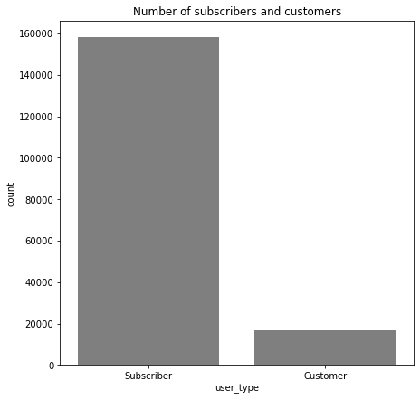

## The gender with the most bike users

> From the gender distribution males use bikes more than the female and other

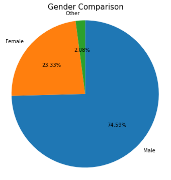

## The gender and trip duration for each user type

> Customers have higher trip duration but now we see this is true across all genders

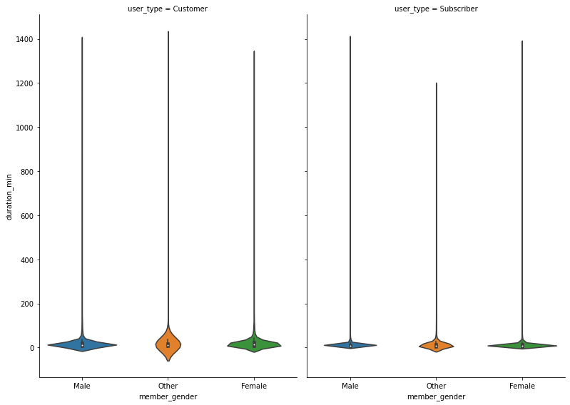

## What is the daily usage of bikes?

> > FordGo bikes are mostly used on Thursdays as seen on the visualization below

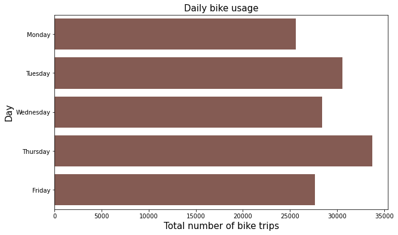

## What is the average trip duration for different user types?

> We can see although subscribers take a lot more trips than customers, the customers however take the most time on trips

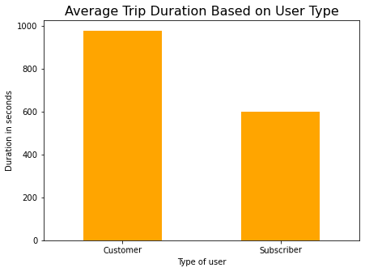

## What is the relation between user type and daily usage ?

> As seen from the visualization, each day of the week the subscribers take the most bike trips than the customer There is a sharp contrast between subscriber and customers

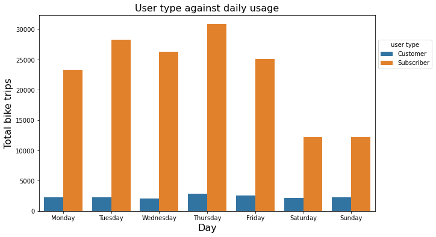

## What is the bike ride comparison between User Groups in each Weekday ?

> As we can see from the visualization, subscribers are the most bike users compared to the customers as expected

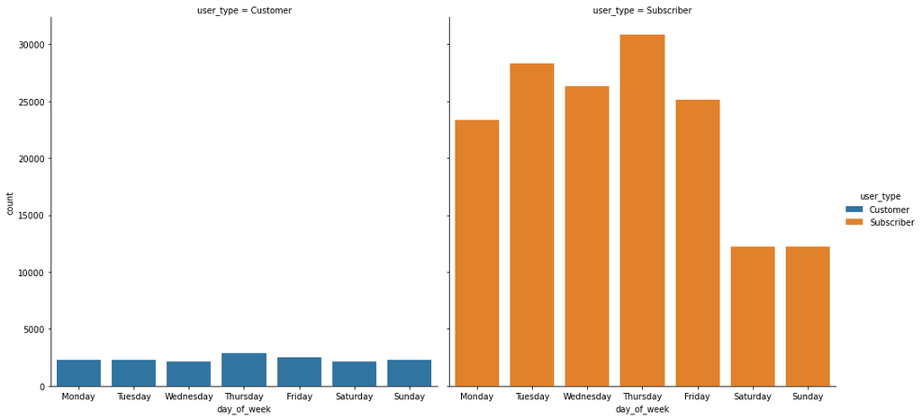

## What is the average trip duration associated with user type and different days of the week?

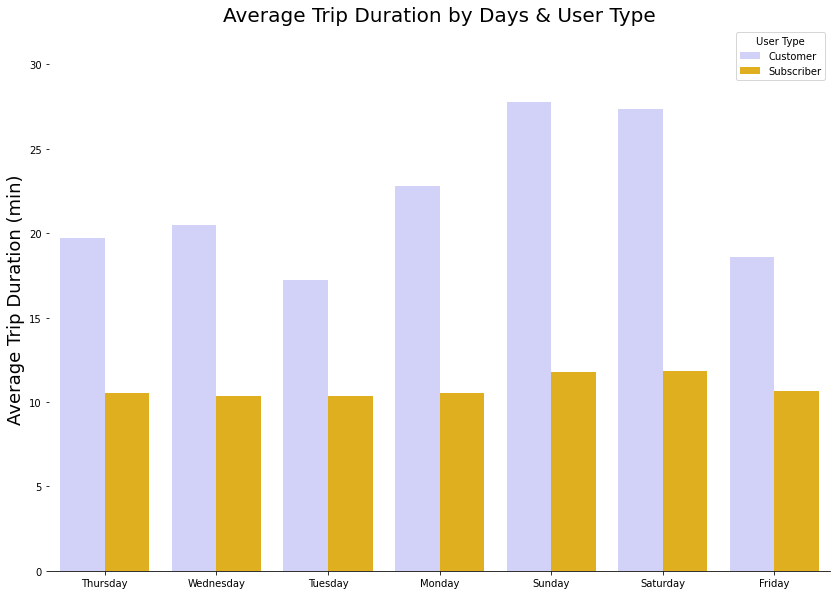

## What is the distribution of trip duration by day and gender?

- As before the average trip duration for females is higher on all days of the week, with Saturday and Sunday have the highest average trip duration.

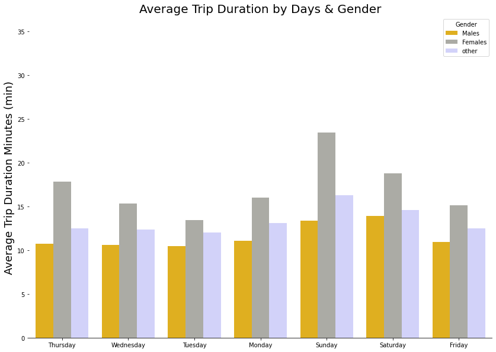